# Solutions to mid-term exam (ds4psy)

# Task 4: Taking stocks

The following table shows the start and end price of 3 stocks on 3 days (d1, d2, d3):

Stock data example showing the start and end prices of the shares of 3 companies on 3 days.

| stock | d1_start | d1_end | d2_start | d2_end | d3_start | d3_end |
| --- | --- | --- | --- | --- | --- | --- |
| Amada | 2.5 | 3.6 | 3.5 | 4.2 | 4.4 | 2.8 |
| Betix | 3.3 | 2.9 | 3.0 | 2.1 | 2.3 | 2.5 |
| Cevis | 4.2 | 4.8 | 4.6 | 3.1 | 3.2 | 3.7 |

**4a.** Create a tibble `st` that contains this data in this (wide) format. (1 point)

**4b.** Transform `st` into a longer table `st_long` that contains 18 rows and only 1 numeric variable for all stock prices. Adjust this table so that the `day` and `time` appear as 2 separate columns. (2 points)

**4c.** Create a graph that shows the 3 stocks’ `end` prices (on the y-axis) over the 3 days (on the x-axis). (1 point)

**4d.** Spread `st_long` into a wider table that contains `start` and `end` prices as 2 distinct variables (columns) for each stock and day. (1 point)

```r
# library(tidyverse)

## (a) Enter stock data (in wide format) as a tibble:
st <- tribble(
  ~stock, ~d1_start, ~d1_end, ~d2_start, ~d2_end, ~d3_start, ~d3_end,
  #-----|----------|--------|----------|--------|----------|--------|
  "Amada",   2.5,     3.6,    3.5,       4.2,      4.4,       2.8,
  "Betix",   3.3,     2.9,    3.0,       2.1,      2.3,       2.5,
  "Cevis",   4.2,     4.8,    4.6,       3.1,      3.2,       3.7
)
dim(st)
```

```
#> [1] 3 7
```

```r
## Note data structure:
## 2 nested factors: day (1 to 3), type (start or end).

## (b) Change from wide to long format
##     that contains the day (d1, d2, d3) and type (start vs. end) as separate columns:
st_long <- st %>%
  gather(d1_start:d3_end, key = "key", value = "val") %>%
  separate(key, into = c("day", "time")) %>%
  arrange(stock, day, time) # optional: arrange rows
st_long
```

```
#> # A tibble: 18 x 4
#>    stock day   time    val
#>    <chr> <chr> <chr> <dbl>
#>  1 Amada d1    end    3.60
#>  2 Amada d1    start  2.50
#>  3 Amada d2    end    4.20
#>  4 Amada d2    start  3.50
#>  5 Amada d3    end    2.80
#>  6 Amada d3    start  4.40
#>  7 Betix d1    end    2.90
#>  8 Betix d1    start  3.30
#>  9 Betix d2    end    2.10
#> 10 Betix d2    start  3.00
#> 11 Betix d3    end    2.50
#> 12 Betix d3    start  2.30
#> 13 Cevis d1    end    4.80
#> 14 Cevis d1    start  4.20
#> 15 Cevis d2    end    3.10
#> 16 Cevis d2    start  4.60
#> 17 Cevis d3    end    3.70
#> 18 Cevis d3    start  3.20
```

```r
## (c) Plot the end values (on the y-axis) of the 3 stocks over 3 days (x-axis):
st_long %>%
  filter(time == "end") %>%
  ggplot(aes(x = day, y = val, color = stock, shape = stock)) +
  geom_point(size = 4) +
  geom_line(aes(group = stock)) +
  ## Pimping plot:
  labs(title = "End prices of stocks",
       x = "Day", y = "End price",
       shape = "Stock:", color = "Stock:") +
  theme_bw()

## (d) Change st_long into a wider format that lists start and end as 2 distinct variables (columns):
st_long %>%
  spread(key = time, value = val) %>%
  mutate(day_nr = parse_integer(str_sub(day, 2, 2))) # optional: get day_nr as integer variable
```

```
#> # A tibble: 9 x 5
#>   stock day     end start day_nr
#>   <chr> <chr> <dbl> <dbl>  <int>
#> 1 Amada d1     3.60  2.50      1
#> 2 Amada d2     4.20  3.50      2
#> 3 Amada d3     2.80  4.40      3
#> 4 Betix d1     2.90  3.30      1
#> 5 Betix d2     2.10  3.00      2
#> 6 Betix d3     2.50  2.30      3
#> 7 Cevis d1     4.80  4.20      1
#> 8 Cevis d2     3.10  4.60      2
#> 9 Cevis d3     3.70  3.20      3
```

```r
pt <- pt + 5  # increment point total
```

# Task 5: Flower power

The `iris` data (contained in R datasets) provides the measurements (in cm) of plant parts (length and width of *sepal* and *petal* parts) for 50 flowers from each of 3 species of iris (called *setosa*, *versicolor*, and *virginica*).

**5a.** Save `datasets::iris` a tibble `ir` that contains this data and inspect it. Are there any missing values? (2 points)

**5b.** Compute a summary table that shows the means of the 4 measurement columns (`Sepal.Length`, `Sepal.Width`, `Petal.Length`, `Petal.Width`) for each of the 3 `Species` (in rows). Save the resulting table of means as a tibble `im1` . (2 points)

**5c.** Create a histogram that shows the distribution of `Sepal.Width` values across all species. (1 point)

**5d.** Create a plot that shows the shape of the distribution of `Sepal.Width` values for each species. (1 point)

**5e.** Create a plot that shows `Petal.Width` as a function of `Sepal.Width` separately (i.e., in 3 facets) for each species. (1 point)

```r
# ?iris

## (a) Turn into tibble and inspect: -----
ir <- as_tibble(datasets::iris)
dim(ir)        # => 150 observations (rows) x 5 variables (columns)
```

```
#> [1] 150   5
```

```r
sum(is.na(ir)) # =>   0 missing values
```

```
#> [1] 0
```

```r
## (b) Compute counts and means by species: -----
im1 <- ir %>%
  group_by(Species) %>%
  summarise(n = n(),
            mn_sep.len = mean(Sepal.Length),
            mn_sep.wid = mean(Sepal.Width),
            mn_pet.len = mean(Petal.Length),
            mn_pet.wid = mean(Petal.Width)
            )

# Print im1 (as table with 4 variables of means):
knitr::kable(im1, caption = "Average iris measures (4 variables of mean values).")
```

Average iris measures (4 variables of mean values).

| Species | n | mn_sep.len | mn_sep.wid | mn_pet.len | mn_pet.wid |
| --- | --- | --- | --- | --- | --- |
| setosa | 50 | 5.006 | 3.428 | 1.462 | 0.246 |
| versicolor | 50 | 5.936 | 2.770 | 4.260 | 1.326 |
| virginica | 50 | 6.588 | 2.974 | 5.552 | 2.026 |

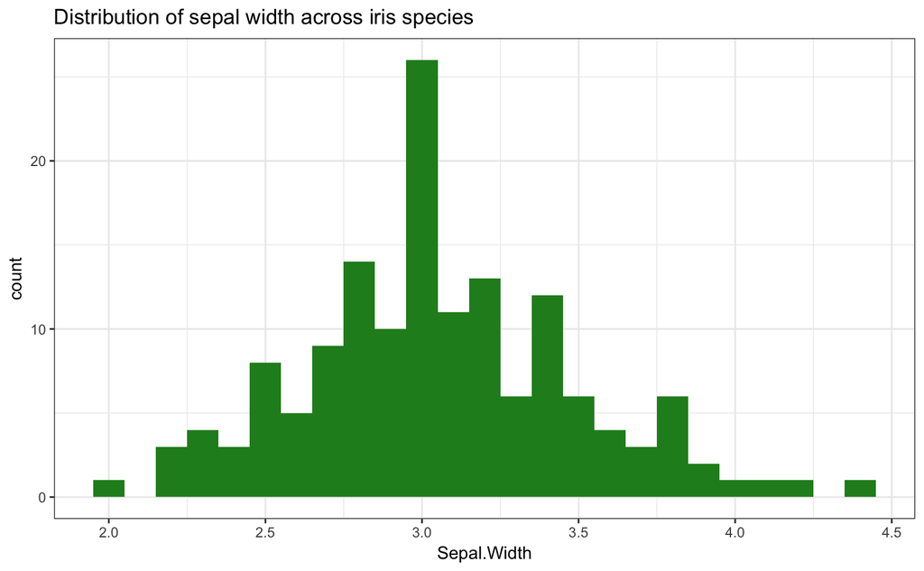

```r
## Graphical exploration: -----

## Distribution of 1 (continuous) variable:

## (c) Distribution of Sepal.Width across species:
ggplot(ir, aes(x = Sepal.Width)) +
  geom_histogram(binwidth = .1, fill = "forestgreen") +
  labs(title = "Distribution of sepal width across iris species") +
  theme_bw()
```

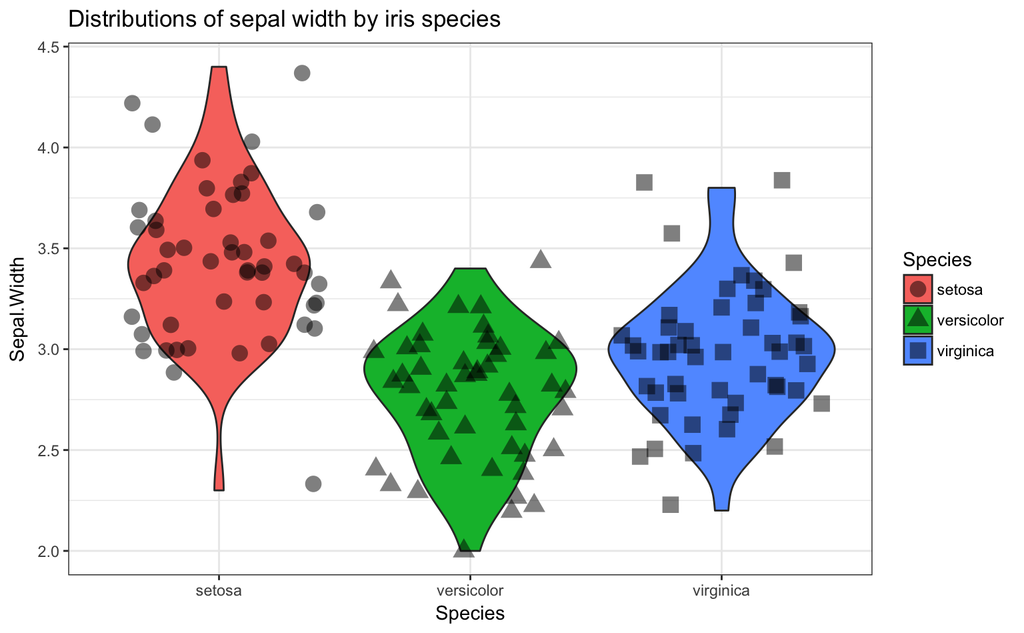

```r
## Distributions/relationships between 2 variables (1 categorical, 1 continuous):

## (d) The distributions of Sepal.Width by species:
ggplot(ir, aes(x = Species, y = Sepal.Width, fill = Species, shape = Species)) +
  geom_violin() +
  geom_point(size = 4, alpha = 1/2, position = "jitter") +
  labs(title = "Distributions of sepal width by iris species") +
  theme_bw()
```

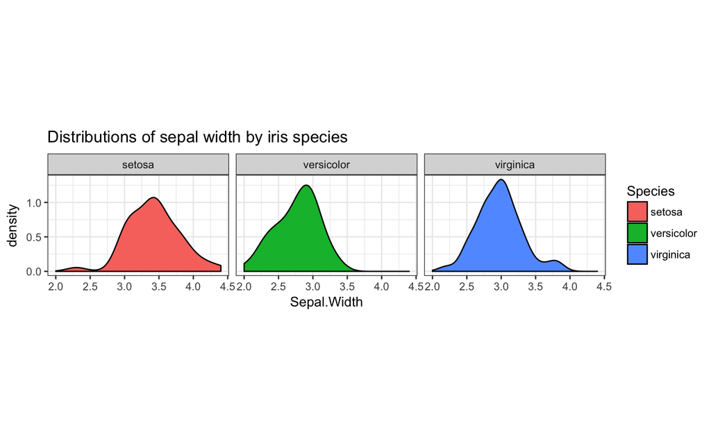

```r
## Alternative solution using density plots:
ggplot(ir, aes(x = Sepal.Width, fill = Species)) +
  facet_wrap(~Species) +
  geom_density() +
  labs(title = "Distributions of sepal width by iris species") +
  coord_fixed() +
  theme_bw()
```

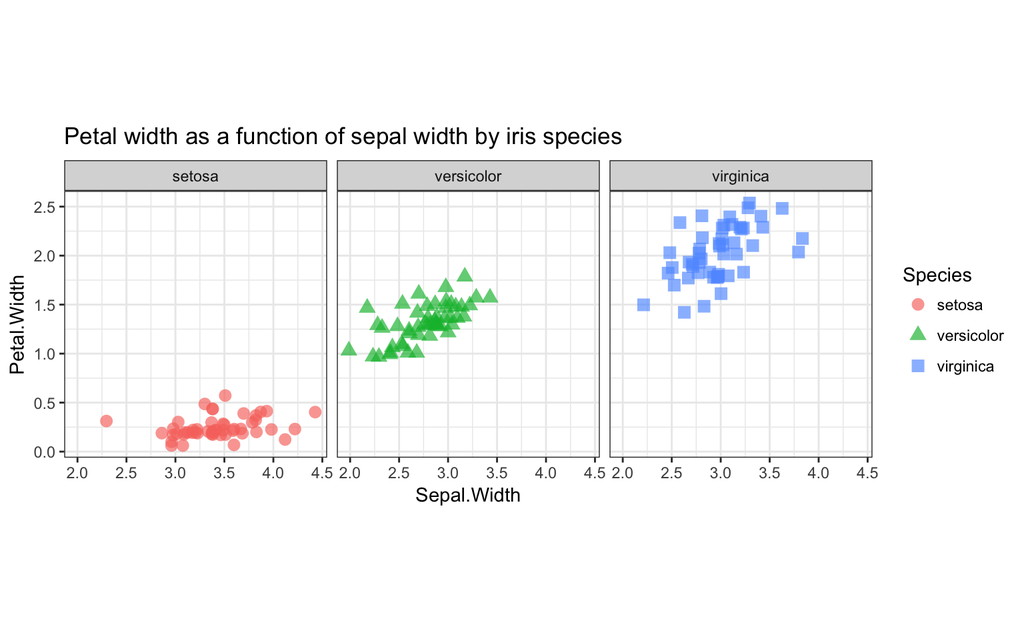

```r
## Relationships between 2 variables (2 continuous):

## (e) Petal.Width as a function of Sepal.Width by iris species:
ggplot(ir, aes(x = Sepal.Width, y = Petal.Width, color = Species, shape = Species)) +
  facet_wrap(~Species) +
  geom_jitter(size = 3, alpha = 2/3) +
  # geom_density2d() +
  coord_fixed() +
  labs(title = "Petal width as a function of sepal width by iris species") +
  theme_bw()
```

```r
pt <- pt + 7  # increment point total

## next: Turn iris df into long format using tidyr::gather -----
## (see below)
```

**5f.** Re-format your tibble `ir` into a tibble `ir_long` which in “long format”. (2 points)

**Hint:** Use `tidyr::gather` and `separate` to turn `ir` into a tibble that contains only 1 dependent variable for the value of measurements (e.g., `val`), but 2 categorical variables that specify the `part` (Sepal vs. Petal) and `metric` (Length vs. Width) of each observation.

**5g.** Use `ir_long` to recompute the subgroup means (for each combination of species, plant part, and metric) computed in **5b.**. Save the resulting table of means as a tibble `im2` and verify that they have not changed from `im1` above. (2 points)

**5h.** Visualize the relationships between the means of `im2` (i.e., the mean measurements by plant part and metric) separately for each species. (2 points)

**Hints:** This task asks for showing the value of a continuous variable (the value of means) as a function of 2 categorical variables (the plant `part` and type of `metric`). Possible solutions could incorporate either `geom_line` or `geom_tile` and use different facets for different `Species`.

**5i.** **Bonus task:** Re-format your tibble `ir_long` (in long format) into a wider tibble `ir_short` that corresponds to the original `ir` dataset. (2 bonus points)

**Hints:** This task calls for applying `tidyr::spread` and `unite` commands to `ir_long`. However, `spread` will encounter an error unless every individual plant is identified by a unique variable (e.g., `id` number). This can be achieved by adding a numeric counter variable `id` (with values of `rep(1:50, 3)`) to `ir` *before* creating `ir_long`.

```r
## Data (from above):
# ?iris
# ir <- as_tibble(datasets::iris)
# ir

## (f) Re-format ir into long format (using tidyr::gather) -----
ir_long <- ir %>%
  mutate(id = rep(1:50, 3)) %>%   # add a unique id to each plant [to enable (i) below]
  gather(Sepal.Length:Petal.Width, key = "type", value = "val") %>%
  separate("type", into = c("part", "metric"), sep = "\\.")

ir_long
```

```
#> # A tibble: 600 x 5
#>    Species    id part  metric   val
#>  * <fct>   <int> <chr> <chr>  <dbl>
#>  1 setosa      1 Sepal Length  5.10
#>  2 setosa      2 Sepal Length  4.90
#>  3 setosa      3 Sepal Length  4.70
#>  4 setosa      4 Sepal Length  4.60
#>  5 setosa      5 Sepal Length  5.00
#>  6 setosa      6 Sepal Length  5.40
#>  7 setosa      7 Sepal Length  4.60
#>  8 setosa      8 Sepal Length  5.00
#>  9 setosa      9 Sepal Length  4.40
#> 10 setosa     10 Sepal Length  4.90
#> # ... with 590 more rows
```

```r
dim(ir_long) # => 600 rows x 5 columns
```

```
#> [1] 600   5
```

```r
## (g) Recompute group counts and means from ir_long: -----
im2 <- ir_long %>%
  group_by(Species, part, metric) %>%
  summarise(n = n(),
            mn_val = mean(val)
            )

# Print im2 (as table with 4 variables of means):
knitr::kable(im2, caption = "Average iris measures (1 variable of mean values).")
```

Average iris measures (1 variable of mean values).

| Species | part | metric | n | mn_val |
| --- | --- | --- | --- | --- |
| setosa | Petal | Length | 50 | 1.462 |
| setosa | Petal | Width | 50 | 0.246 |
| setosa | Sepal | Length | 50 | 5.006 |
| setosa | Sepal | Width | 50 | 3.428 |
| versicolor | Petal | Length | 50 | 4.260 |
| versicolor | Petal | Width | 50 | 1.326 |
| versicolor | Sepal | Length | 50 | 5.936 |
| versicolor | Sepal | Width | 50 | 2.770 |
| virginica | Petal | Length | 50 | 5.552 |
| virginica | Petal | Width | 50 | 2.026 |
| virginica | Sepal | Length | 50 | 6.588 |
| virginica | Sepal | Width | 50 | 2.974 |

```r
## Check: Compare sums of all means in im1 vs. im2:
sum1 <- sum(im1$mn_sep.len) + sum(im1$mn_sep.wid) +
        sum(im1$mn_pet.len) + sum(im1$mn_pet.wid)  # => 41.574
sum2 <- sum(im2$mn_val)  # => 41.574
sum1 == sum2             # => TRUE (qed)
```

```
#> [1] TRUE
```

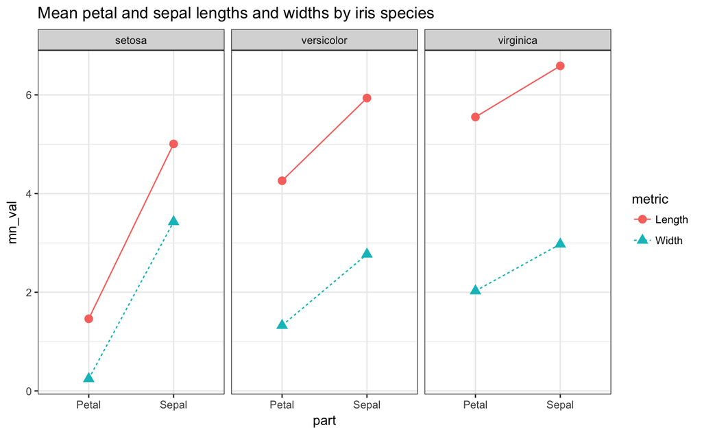

```r
## Showing the value of a continuous variable by 2 categorical variables: -----

## (h) Visualize the means of im2 (i.e., mean measurements by plant part and metric)
##     as a line plot separately for each species:
ggplot(im2, aes(x = part, y = mn_val, group = metric, color = metric)) +
  facet_wrap(~Species) +
  geom_point(aes(shape = metric), size = 3) +
  geom_line(aes(linetype = metric)) +
  labs(title = "Mean petal and sepal lengths and widths by iris species") +
  theme_bw()
```

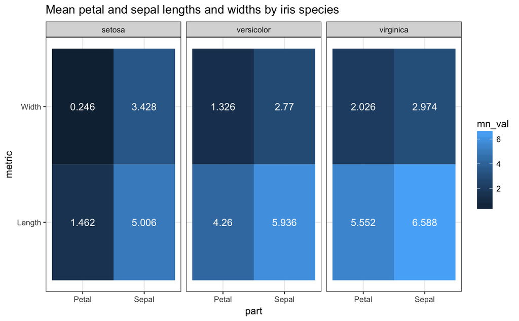

```r
## Alternative solution using tile plots:
ggplot(im2, aes(x = part, y = metric)) +
  facet_wrap(~Species) +
  geom_tile(aes(fill = mn_val)) +
  geom_text(aes(label = mn_val), color = "white") +
  labs(title = "Mean petal and sepal lengths and widths by iris species") +
  theme_bw()
```

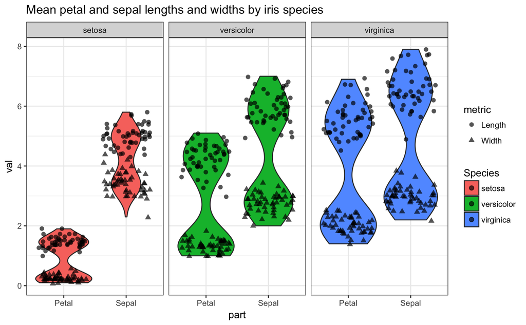

```r
## Alternative: Using raw values (ir_long) to visualize the distributions
##              of val as a function of Species, plant part, and metric:
ggplot(ir_long, aes(x = part, y = val, fill = Species)) +
  facet_wrap(~Species) +
  geom_violin() +
  geom_jitter(aes(shape = metric), size = 2, alpha = 2/3) +
  labs(title = "Mean petal and sepal lengths and widths by iris species") +
  theme_bw()
```

```r
## (i) Bonus task: -----

## See (f) above for the additional id-column for each plant:
## mutate(id = rep(1:50, 3)) %>% ...

## Re-format ir_long into shorter format (using tidyr::spread) -----
ir_short <- ir_long %>%
  unite(type, part, metric, sep = ".") %>%  # unite part and metric into "type" column
  spread(key = type, value = val) %>%       # spread "type" variable into multiple columns
  arrange(Species, id)

ir_short
```

```
#> # A tibble: 150 x 6
#>    Species    id Petal.Length Petal.Width Sepal.Length Sepal.Width
#>    <fct>   <int>        <dbl>       <dbl>        <dbl>       <dbl>
#>  1 setosa      1         1.40       0.200         5.10        3.50
#>  2 setosa      2         1.40       0.200         4.90        3.00
#>  3 setosa      3         1.30       0.200         4.70        3.20
#>  4 setosa      4         1.50       0.200         4.60        3.10
#>  5 setosa      5         1.40       0.200         5.00        3.60
#>  6 setosa      6         1.70       0.400         5.40        3.90
#>  7 setosa      7         1.40       0.300         4.60        3.40
#>  8 setosa      8         1.50       0.200         5.00        3.40
#>  9 setosa      9         1.40       0.200         4.40        2.90
#> 10 setosa     10         1.50       0.100         4.90        3.10
#> # ... with 140 more rows
```

```r
## Verify identity of all measurement values in ir and ir_short:
all.equal(ir$Sepal.Length, ir_short$Sepal.Length) &
all.equal(ir$Sepal.Width,  ir_short$Sepal.Width)  &
all.equal(ir$Petal.Length, ir_short$Petal.Length) &
all.equal(ir$Petal.Width,  ir_short$Petal.Width)  # => TRUE (qed)
```

```
#> [1] TRUE
```

```r
pt <- pt + (6 + 0)  # increment point total (leaving out 2 bonus points)
```

# Task 6: Not all outliers are alike

This task examines the statistical definition of outliers and uses a generated dataset (entitled `out.csv` and available at http://rpository.com/ds4psy/mt/out.csv). Use the following `read_csv()` command to obtain and load it into R:

```r
## Load data (as comma-separated file):
data <- read_csv("http://rpository.com/ds4psy/mt/out.csv")  # from online source

## Alternatively (from local source):
# data <- read_csv("out.csv")  # from current directory
```

An *outlier* can be defined as an individual whose value in some metric deviates by more than a given criterion (e.g., 2 standard deviations) from the mean. But this definition is incomplete unless it also specifies an appropriate reference group. This task explores the implications of different reference groups.

**6a.** Save the data into a tibble `data` and report its number of observations and variables. (1 point)

**6b.** How many missing data values are there in `data`? (1 point)

**6c.** What is the gender (or `sex`) distribution in this sample? (1 point)

**6d.** Create a plot that shows the distribution of `height` values for each gender. (1 point)

**6e.** Compute 2 new variables that signal and distinguish between 2 types of outliers in terms of `height`:

1. outliers relative to the `height` of the *overall sample* (i.e., individuals with `height` values deviating more than 2 SD from the overall mean of `height`) (1 point);
2. outliers relative to the `height` of *some subgroup*’s mean and SD. Here, a suitable subgroup to consider is every person’s gender (i.e., individuals with `height` values deviating more than 2 SD from the mean `height` of their own gender). (1 point)

**Hints:** As both variable signal whether or not someone is an outlier they should be defined as logicals (being either `TRUE` or `FALSE`) and added as new columns to `data` (via appropriate `mutate` commands). While the 1st variable can be computed based on the mean and SD of the overall sample, the 2nd variable can be computed after grouping `data` by gender and then computing and using the corresponding mean and SD values. The absolute difference between 2 numeric values `x` and `y` is provided by `abs(x - y)`.

**6f.** Use the 2 new variables to define and identify 2 subgroups of people:

1. `out_1`: Individuals (females and males) with `height` values that are outliers relative to *both* the entire sample *and* the sample of their own gender. How many such individuals are in `data`? (1 point)
2. `out_2`: Individuals (females and males) with `height` values that are *not* outliers relative to the entire population, but *are* outliers relative to their own gender. How many such individuals are in `data`? (1 point)

**6g.** **Bonus task:** Visualize the raw values and distributions of `height` for both types of outliers (`out_1` and `out_2`) in 2 separate plots and describe the `height` and `sex` combination of the individuals shown in each plot. (2 bonus points)

```r
## (a) Load and inspect data:
# data <- read_csv("out.csv") # read in csv-file
# data <- as_tibble(data)   # if data is not already a tibble
dim(data)  # => 1000 observations (rows) x 3 variables (columns)
```

```
#> [1] 1000    3
```

```r
## (b) Missing data points:
sum(is.na(data))  # => 18 missing values
```

```
#> [1] 18
```

```r
## (c) Gender distribution:
data %>%
  group_by(sex) %>%
  count()
```

```
#> # A tibble: 2 x 2
#> # Groups: sex [2]
#>   sex        n
#>   <chr>  <int>
#> 1 female   507
#> 2 male     493
```

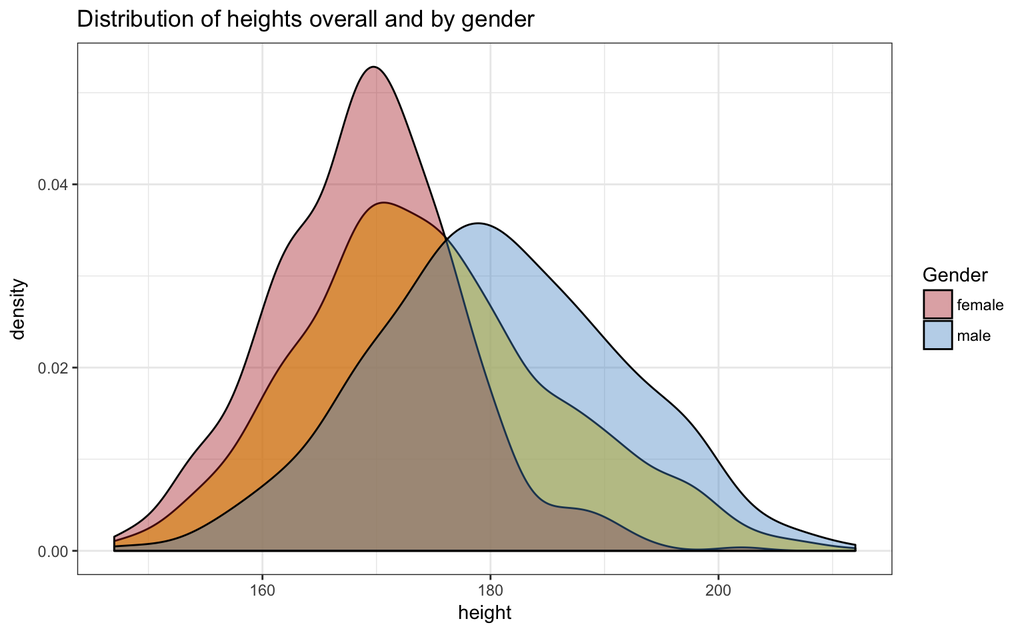

```r
# => 50.7% females, 49.3% males.

## (d) Distributions of `height` as density plot:
ggplot(data, aes(x = height)) +
  geom_density(fill = "gold", alpha = 2/3) +
  geom_density(aes(fill = sex), alpha = 2/5) +
  labs(title = "Distribution of heights overall and by gender",
       fill = "Gender") +
  scale_fill_manual(values = c("firebrick", "steelblue3")) +
  theme_bw()
```

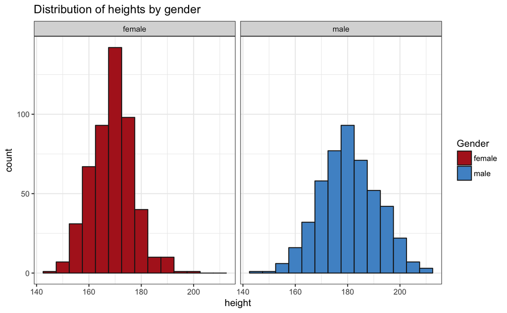

```r
# Note: To avoid the Warning about removing 18 cases with NA-values,
#       we could first filter out those cases:
# non_NA_data <- filter(data, !is.na(height))

## Alternative solution as 2 histograms:
ggplot(data) +
  facet_wrap(~sex) +
  geom_histogram(aes(x = height, fill = sex), binwidth = 5, color = "grey10") +
  labs(title = "Distribution of heights by gender",
       fill = "Gender") +
  scale_fill_manual(values = c("firebrick", "steelblue3")) +
  theme_bw()
```

```r
## (+) Included in (e), but also possible to do separately:
##     Compute the number, means and SD of height values in 2 ways:
{
  ## 1. overall:
  data %>%
    summarise(n = n(),
              n_not_NA = sum(!is.na(height)),
              mn_height = mean(height, na.rm = TRUE),
              sd_height = sd(height, na.rm = TRUE))

  ## 2. by gender:
  data %>%
    group_by(sex) %>%
    summarise(n = n(),
              n_not_NA = sum(!is.na(height)),
              mn_height = mean(height, na.rm = TRUE),
              sd_height = sd(height, na.rm = TRUE))
  }
```

```
#> # A tibble: 2 x 5
#>   sex        n n_not_NA mn_height sd_height
#>   <chr>  <int>    <int>     <dbl>     <dbl>
#> 1 female   507      501       169      8.19
#> 2 male     493      481       181     11.0
```

```r
## (e) Detecting and marking outliers (by logical variables): -----

## Compute the means, SDs, and corresponding outliers in 2 ways:
crit <- 2  # criterion value for detecting outliers (in SD units)

data_out <- data %>%
  # 1. Compute means, SD, and outliers for overall sample:
  mutate(mn_height  = mean(height, na.rm = TRUE),
         sd_height  = sd(height, na.rm = TRUE),
         out_height = abs(height - mn_height) > (crit * sd_height)) %>%
  group_by(sex) %>%
  # 2. Compute same metrics for subgroups:
  mutate(mn_sex_height  = mean(height, na.rm = TRUE),
         sd_sex_height  = sd(height, na.rm = TRUE),
         out_sex_height = abs(height - mn_sex_height) > (crit * sd_sex_height))

# data_out

## (f) Identify 2 types of outliers: -----

## 1. Outliers relative to the entire population AND to their own gender:
out_1 <- data_out %>%
  filter(out_height & out_sex_height) %>%
  arrange(sex, height)

nrow(out_1) # => 21 individuals.
```

```
#> [1] 21
```

```r
## 2. Outliers relative to their own gender, but NOT relative to the entire population:
out_2 <- data_out %>%
  filter(!out_height & out_sex_height) %>%
  arrange(sex, height)

nrow(out_2) # => 24 individuals.
```

```
#> [1] 24
```

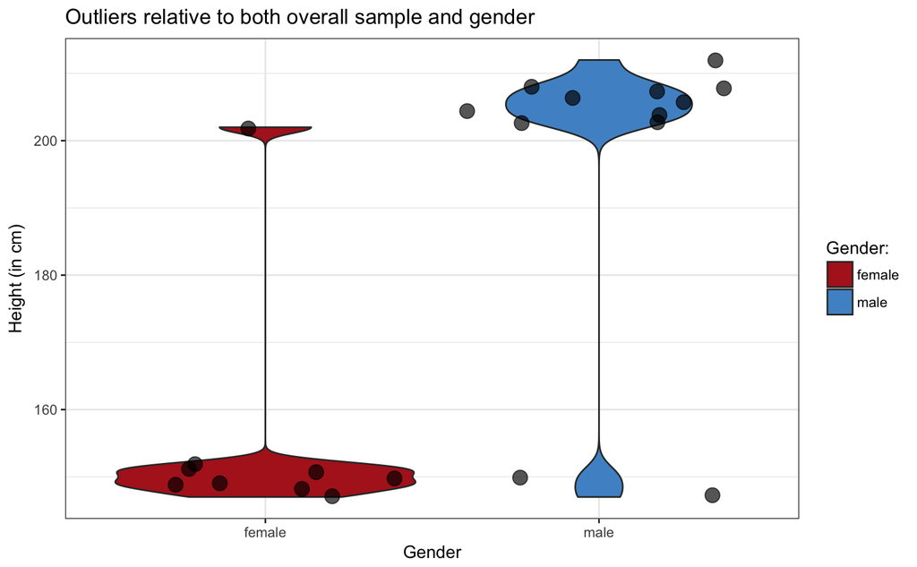

```r
## (g) Bonus task:
## Visualization and interpretation of both types of outliers: -----

## 1. Showing out_1:
ggplot(out_1, aes(x = sex, y = height)) +
  geom_violin(aes(fill = sex)) +
  geom_jitter(size = 4, alpha = 2/3) +
  scale_fill_manual(values = c("firebrick", "steelblue3")) +
  labs(title = "Outliers relative to both overall sample and gender",
       x = "Gender", y = "Height (in cm)",
       fill = "Gender:") +
  theme_bw()
```

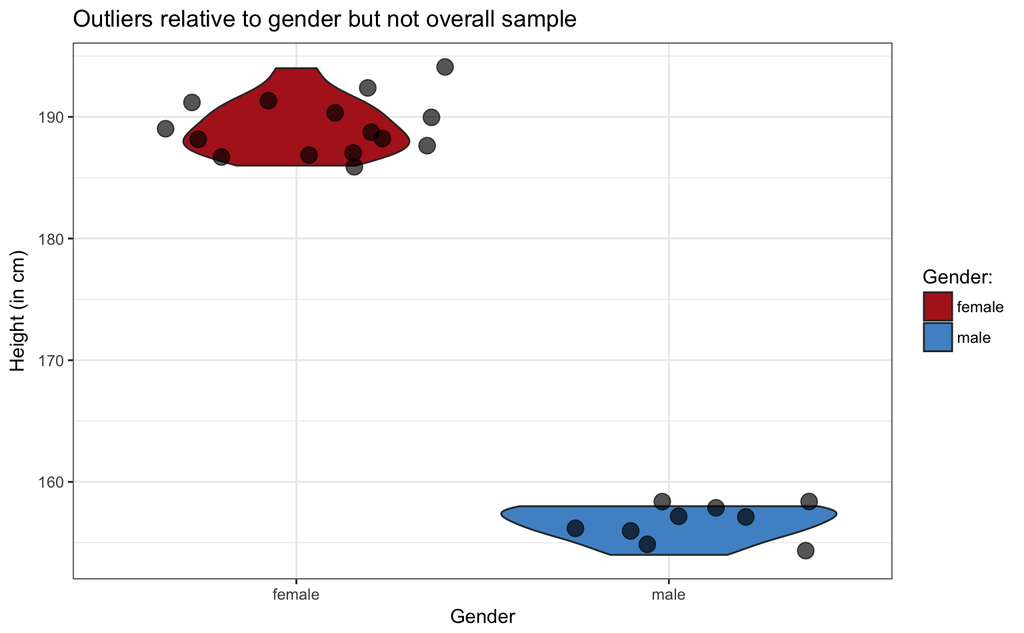

```r
# Interpretation:
# `out_1` contains mostly short women (except for 1 tall woman)
#  and mostly tall men (except for 2 short men).

## 2. Showing out_2:
ggplot(out_2, aes(x = sex, y = height)) +
  geom_violin(aes(fill = sex)) +
  geom_jitter(size = 4, alpha = 2/3) +
  scale_fill_manual(values = c("firebrick", "steelblue3")) +
  labs(title = "Outliers relative to gender but not overall sample",
       x = "Gender", y = "Height (in cm)",
       fill = "Gender:") +
  theme_bw()
```

```r
# Interpretation:
# `out_2` contains individuals which are either tall women or short men.

pt <- pt + (8 + 0)  # increment point total (leaving out 2 bonus points)
```

## Counting tasks and points

This exam contains **6 tasks** for a total of **50 points** (plus 4 possible bonus points).

[Last update on 2018-07-13 15:41:37 by [hn](http://neth.de/).]